# 320FinalP (1) (1)

**How to Score Goals** **Fall 2025 Data Science Project**

**Introduction** The topic is what statistic or measurable of NHL players leads to them scoring more goals. I am interested in answering this question becuase I play hockey, and if one mesurable is releated to increased scoring it can be used to predict player sucsess or determine what ways to train.

```python
import pandas as pd
#NHL player skating data
tables1 = pd.read_html("https://thestanleycap.com/reports/edge/?season=20242025&game_type=2&tricode=ALL&position=ALL&games_played=1&report=edge_skating_report")   # returns list of tables on the page
skating_foward_df = tables1[0]
#NHL Fowards Stats
tables2 = pd.read_html("https://thestanleycap.com/reports/skaters/?season=20242025&game_type=2&report=individual_skater_report&strength=5v5&tricode=ALL&position=Forwards&toi=10")   # returns list of tables on the page
stats_fowards_df = tables2[0]
#NHL Player Shooting stats
table4 = pd.read_html("https://thestanleycap.com/reports/edge/?season=20242025&game_type=2&tricode=ALL&position=Forwards&games_played=10&report=edge_shooting_report")
shooting_forwards_df = table4[0]

#drop the id an extra id column that will not be used
shooting_forwards_df = shooting_forwards_df.drop(columns=['Unnamed: 0'])
skating_forward_df = skating_foward_df.drop(columns=['Unnamed: 0'])
stats_forwards_df = stats_fowards_df.drop(columns=['Unnamed: 0'])

shooting_forwards_df.isna().sum()
```

|  | 0 |
| --- | --- |
| Player | 0 |
| Team | 0 |
| Pos | 0 |
| GP | 0 |
| Top Speed (mph) | 0 |
| Average Speed | 0 |
| Shots 100+ | 0 |
| Shots 90+ | 0 |
| % High Danger | 0 |
| % Mid Range | 0 |
| % Long Range | 0 |

**dtype:** int64

```python
display(shooting_forwards_df.isna().sum())
display(skating_forward_df.isna().sum())
display(stats_forwards_df.isna().sum())
```

|  | 0 |
| --- | --- |
| Player | 0 |
| Team | 0 |
| Pos | 0 |
| GP | 0 |
| Top Speed (mph) | 0 |
| Average Speed | 0 |
| Shots 100+ | 0 |
| Shots 90+ | 0 |
| % High Danger | 0 |
| % Mid Range | 0 |
| % Long Range | 0 |

**dtype:** int64

|  | 0 |
| --- | --- |
| Player | 0 |
| Team | 0 |
| Pos | 0 |
| GP | 0 |
| Top Speed | 0 |
| Distance Skated | 0 |
| Average Speed | 0 |
| Bursts>20 per mile | 0 |
| ES Dist. Skated | 0 |
| ES Avg. Speed | 0 |

**dtype:** int64

|  | 0 |
| --- | --- |
| Player | 0 |
| Team(s) | 0 |
| Pos | 0 |
| GP | 0 |
| TOI | 0 |
| G | 0 |
| A Pass | 0 |
| A Shot | 0 |
| Pts | 0 |
| SA | 0 |
| SOG | 0 |
| SH% | 11 |
| SA Dist | 6 |
| xG | 0 |
| G-xG | 0 |
| xSH% | 11 |
| SH%AE | 11 |

**dtype:** int64

Next to make sure the new dataframes have the correct information, we take a peak inside by displaying them.

```python
display(skating_forward_df)
display(stats_fowards_df)
display(shooting_forwards_df)
```

|  | Player | Team | Pos | GP | Top Speed | Distance Skated | Average Speed | Bursts>20 per mile | ES Dist. Skated | ES Avg. Speed |
| --- | --- | --- | --- | --- | --- | --- | --- | --- | --- | --- |
| 0 | Ryan Suter | STL | D | 82 | 21.14 | 230.06 | 8.65 | 0.08 | 210.58 | 8.85 |
| 1 | Brent Burns | CAR | D | 82 | 21.72 | 245.67 | 8.58 | 0.11 | 201.30 | 8.72 |
| 2 | Corey Perry | EDM | R | 81 | 21.06 | 141.45 | 8.78 | 0.16 | 130.02 | 9.06 |
| 3 | Alex Ovechkin | WSH | L | 65 | 21.98 | 170.40 | 8.87 | 0.09 | 139.04 | 9.47 |
| 4 | Evgeni Malkin | PIT | C | 68 | 22.01 | 209.77 | 10.41 | 0.23 | 183.99 | 10.63 |
| ... | ... | ... | ... | ... | ... | ... | ... | ... | ... | ... |
| 915 | Nikita Prishchepov | COL | C | 10 | 21.17 | 10.96 | 10.33 | 0.82 | 10.96 | 10.33 |
| 916 | Jack Williams | CBJ | R | 1 | 21.28 | 1.79 | 9.66 | 1.67 | 1.79 | 9.66 |
| 917 | Karsen Dorwart | PHI | L | 5 | 22.12 | 9.10 | 9.95 | 1.10 | 8.30 | 10.02 |
| 918 | Quinn Hutson | EDM | R | 2 | 20.84 | 4.42 | 9.87 | 0.91 | 4.39 | 9.90 |
| 919 | Tim Washe | ANA | C | 2 | 21.47 | 2.73 | 10.61 | 2.93 | 2.73 | 10.61 |

920 rows × 10 columns

|  | Unnamed: 0 | Player | Team(s) | Pos | GP | TOI | G | A Pass | A Shot | Pts | SA | SOG | SH% | SA Dist | xG | G-xG | xSH% | SH%AE |
| --- | --- | --- | --- | --- | --- | --- | --- | --- | --- | --- | --- | --- | --- | --- | --- | --- | --- | --- |
| 0 | NaN | Corey Perry | EDM | R | 81 | 821:19 | 13 | 6 | 0 | 19 | 118 | 81 | 16.0 | 24.3 | 10.4 | 2.6 | 12.9 | 3.2 |
| 1 | NaN | Alex Ovechkin | WSH | L | 65 | 812:38 | 21 | 15 | 2 | 38 | 206 | 137 | 15.3 | 34.8 | 12.5 | 8.5 | 9.1 | 6.2 |
| 2 | NaN | Evgeni Malkin | PIT | C | 68 | 967:47 | 10 | 14 | 1 | 25 | 114 | 82 | 12.2 | 24.2 | 9.6 | 0.4 | 11.7 | 0.5 |
| 3 | NaN | Sidney Crosby | PIT | C | 80 | 1250:12 | 16 | 32 | 7 | 55 | 228 | 150 | 10.7 | 28.4 | 15.8 | 0.2 | 10.6 | 0.1 |
| 4 | NaN | Anze Kopitar | LAK | C | 81 | 1129:43 | 16 | 18 | 2 | 36 | 113 | 77 | 20.8 | 25.3 | 8.9 | 7.1 | 11.6 | 9.2 |
| ... | ... | ... | ... | ... | ... | ... | ... | ... | ... | ... | ... | ... | ... | ... | ... | ... | ... | ... |
| 584 | NaN | Nikita Prishchepov | COL | C | 10 | 63:40 | 0 | 0 | 0 | 0 | 7 | 4 | 0.0 | 47.0 | 0.2 | -0.2 | 6.0 | -6.0 |
| 585 | NaN | Jack Williams | CBJ | R | 1 | 11:09 | 0 | 0 | 0 | 0 | 1 | 0 | NaN | 54.1 | 0.0 | -0.0 | NaN | NaN |
| 586 | NaN | Karsen Dorwart | PHI | L | 5 | 49:14 | 0 | 0 | 0 | 0 | 5 | 4 | 0.0 | 22.0 | 0.4 | -0.4 | 9.6 | -9.6 |
| 587 | NaN | Quinn Hutson | EDM | R | 2 | 21:34 | 0 | 0 | 0 | 0 | 2 | 0 | NaN | 56.7 | 0.0 | -0.0 | NaN | NaN |
| 588 | NaN | Tim Washe | ANA | C | 2 | 15:28 | 0 | 0 | 0 | 0 | 6 | 2 | 0.0 | 33.3 | 0.3 | -0.3 | 17.1 | -17.1 |

589 rows × 18 columns

|  | Player | Team | Pos | GP | Top Speed (mph) | Average Speed | Shots 100+ | Shots 90+ | % High Danger | % Mid Range | % Long Range |
| --- | --- | --- | --- | --- | --- | --- | --- | --- | --- | --- | --- |
| 0 | Corey Perry | EDM | R | 81 | 94.70 | 51.81 | 0 | 1 | 66.2 | 28.8 | 5.0 |
| 1 | Alex Ovechkin | WSH | L | 65 | 98.96 | 67.84 | 0 | 29 | 21.2 | 56.6 | 22.2 |
| 2 | Evgeni Malkin | PIT | C | 68 | 90.34 | 52.72 | 0 | 1 | 49.0 | 42.2 | 8.8 |
| 3 | Sidney Crosby | PIT | C | 80 | 94.48 | 53.08 | 0 | 2 | 58.9 | 31.1 | 9.9 |
| 4 | Anze Kopitar | LAK | C | 81 | 86.37 | 54.57 | 0 | 0 | 55.1 | 35.9 | 9.0 |
| ... | ... | ... | ... | ... | ... | ... | ... | ... | ... | ... | ... |
| 489 | Collin Graf | SJS | R | 33 | 83.58 | 55.62 | 0 | 0 | 53.6 | 39.3 | 7.1 |
| 490 | Juha Jaaska | CAR | L | 18 | 75.31 | 49.81 | 0 | 0 | 42.9 | 28.6 | 28.6 |
| 491 | Maxim Tsyplakov | NYI | R | 77 | 88.50 | 53.86 | 0 | 0 | 42.6 | 47.9 | 9.6 |
| 492 | Jere Innala | COL | L | 17 | 80.98 | 60.91 | 0 | 0 | 75.0 | 25.0 | 0.0 |
| 493 | Nikita Prishchepov | COL | C | 10 | 78.61 | 65.25 | 0 | 0 | 25.0 | 0.0 | 75.0 |

494 rows × 11 columns

```python
# Create a mapping from abbreviations to full names

team_name_mapping = {
    'ANA': 'Anaheim Ducks', 'ARI': 'Arizona Coyotes', 'BOS': 'Boston Bruins', 'BUF': 'Buffalo Sabres',
    'CGY': 'Calgary Flames', 'CAR': 'Carolina Hurricanes', 'CHI': 'Chicago Blackhawks', 'COL': 'Colorado Avalanche',
    'CBJ': 'Columbus Blue Jackets', 'DAL': 'Dallas Stars', 'DET': 'Detroit Red Wings', 'EDM': 'Edmonton Oilers',
    'FLA': 'Florida Panthers', 'LAK': 'Los Angeles Kings', 'MIN': 'Minnesota Wild', 'MTL': 'Montreal Canadiens',
    'NSH': 'Nashville Predators', 'NJD': 'New Jersey Devils', 'NYI': 'New York Islanders', 'NYR': 'New York Rangers',
    'OTT': 'Ottawa Senators', 'PHI': 'Philadelphia Flyers', 'PIT': 'Pittsburgh Penguins', 'SJS': 'San Jose Sharks',
    'SEA': 'Seattle Kraken', 'STL': 'St. Louis Blues', 'TBL': 'Tampa Bay Lightning', 'TOR': 'Toronto Maple Leafs',
    'VAN': 'Vancouver Canucks', 'VGK': 'Vegas Golden Knights', 'WSH': 'Washington Capitals', 'WPG': 'Winnipeg Jets',
    'UTA': 'Utah Mammoth'
}
```

Now I start cleaning the data. This involves changing Column names to fit the mapping, renaming columns so they don't have the name of a column in another dataframe that may get merged later. It also involves combining columns into one for better clarity and less variables.

```python
#Replace abriviations with the team name
skating_forward_df['Team'] = skating_forward_df['Team'].replace(team_name_mapping)
#Rename the Column Average Speed -> Avg Skating speed to avoid mixup with avg shot speed in other df
skating_foward_df = skating_forward_df.rename(columns={'Average Speed': 'Avg Skating Speed'})
#Fix Column title
stats_fowards_df = stats_forwards_df.rename(columns={'Team(s)': 'Team'})
shooting_fowards_df = shooting_forwards_df.rename(columns={'Team(s)': 'Team'})
#More renaming
shooting_fowards_df = shooting_fowards_df.rename(columns = {'Top Speed (mph)' : 'Top Shot Speed', 'Average Speed': 'Avg Shooting Speed'})
#Map Team name with other df
stats_fowards_df['Team'] = stats_fowards_df['Team'].replace(team_name_mapping)
shooting_fowards_df['Team'] = shooting_fowards_df['Team'].replace(team_name_mapping)
#combining two catagories for assist into one
stats_fowards_df['Assist']  = stats_fowards_df['A Pass'] + stats_fowards_df['A Shot']
#dropping the catagories i no longer need after combining
stats_fowards_df = stats_fowards_df.drop(columns=['A Pass', 'A Shot'])
```

I have interesting data to work with, but they are across three different dataframes. I want the columns i am interested in one dataframe. This will make it easier to call the data and plot it later.

```python
#using .merge I combine the three dataframes.
combined_edge = shooting_fowards_df.merge(skating_foward_df, on='Player', how='inner')
full_forward_stats = combined_edge.merge(stats_fowards_df, on='Player', how='inner')

#To clean the time on ice column into a integer
full_forward_stats['TOI_minutes'] = (
    full_forward_stats['TOI']
    .str.split(':')
    .apply(lambda x: int(x[0]) + int(x[1]) / 60)
)
#after combining I have some repeat values which I want to drop
full_forward_stats = full_forward_stats.drop(columns=['Team_x', 'Pos_x', 'Team_y','Pos_y','TOI', 'GP_x'])
full_forward_stats = full_forward_stats.rename(columns={'TOI_minutes': 'TOI'})
```

Now I want to standardize stats to per game to reduce the influence of playing more games leading to more goals. This is the last bit of cleaning before moving on to analyzing the data.

```python
#Standardize player stats to per game.
#Start with a empty dataframe
stats_per_game = pd.DataFrame()
#start adding the catagories I want, this just consist of the catagory divided by the amount of games that player played.
stats_per_game['Player'] = full_forward_stats['Player']
stats_per_game['TOI'] = full_forward_stats['TOI']
stats_per_game['Goals'] = full_forward_stats['G'] / full_forward_stats['GP']
stats_per_game['Assist'] = full_forward_stats['Assist'] / full_forward_stats['GP']
stats_per_game['SOG'] = full_forward_stats['SOG'] / full_forward_stats['GP']
stats_per_game['Bursts>20'] = full_forward_stats['Bursts>20 per mile'] / full_forward_stats['GP']
stats_per_game['Top Shot Speed'] = full_forward_stats['Top Shot Speed']
stats_per_game['Avg Shooting Speed'] = full_forward_stats['Avg Shooting Speed']
stats_per_game['Top Speed'] = full_forward_stats['Top Speed']
stats_per_game['Avg Skating Speed'] = full_forward_stats['Avg Skating Speed']
stats_per_game['SH%'] = full_forward_stats['SH%']
stats_per_game['S%_on_Goal'] = full_forward_stats['SOG'] / full_forward_stats['SA']
stats_per_game['PTS'] = full_forward_stats['Pts']
display(stats_per_game)
```

|  | Player | TOI | Goals | Assist | SOG | Bursts>20 | Top Shot Speed | Avg Shooting Speed | Top Speed | Avg Skating Speed | SH% | S%_on_Goal | PTS |
| --- | --- | --- | --- | --- | --- | --- | --- | --- | --- | --- | --- | --- | --- |
| 0 | Corey Perry | 821.316667 | 0.160494 | 0.074074 | 1.000000 | 0.001975 | 94.70 | 51.81 | 21.06 | 8.78 | 16.0 | 0.686441 | 19 |
| 1 | Alex Ovechkin | 812.633333 | 0.323077 | 0.261538 | 2.107692 | 0.001385 | 98.96 | 67.84 | 21.98 | 8.87 | 15.3 | 0.665049 | 38 |
| 2 | Evgeni Malkin | 967.783333 | 0.147059 | 0.220588 | 1.205882 | 0.003382 | 90.34 | 52.72 | 22.01 | 10.41 | 12.2 | 0.719298 | 25 |
| 3 | Sidney Crosby | 1250.200000 | 0.200000 | 0.487500 | 1.875000 | 0.007500 | 94.48 | 53.08 | 22.54 | 9.72 | 10.7 | 0.657895 | 55 |
| 4 | Anze Kopitar | 1129.716667 | 0.197531 | 0.246914 | 0.950617 | 0.002840 | 86.37 | 54.57 | 21.48 | 10.12 | 20.8 | 0.681416 | 36 |
| ... | ... | ... | ... | ... | ... | ... | ... | ... | ... | ... | ... | ... | ... |
| 489 | Collin Graf | 400.300000 | 0.090909 | 0.090909 | 0.848485 | 0.023030 | 83.58 | 55.62 | 22.57 | 9.64 | 10.7 | 0.666667 | 6 |
| 490 | Juha Jaaska | 156.583333 | 0.000000 | 0.166667 | 0.611111 | 0.052222 | 75.31 | 49.81 | 21.89 | 9.95 | 0.0 | 0.611111 | 3 |
| 491 | Maxim Tsyplakov | 1010.033333 | 0.103896 | 0.298701 | 1.324675 | 0.005325 | 88.50 | 53.86 | 22.33 | 9.48 | 7.8 | 0.621951 | 31 |
| 492 | Jere Innala | 116.050000 | 0.000000 | 0.000000 | 0.411765 | 0.014118 | 80.98 | 60.91 | 21.30 | 10.15 | 0.0 | 0.466667 | 0 |
| 493 | Nikita Prishchepov | 63.666667 | 0.000000 | 0.000000 | 0.400000 | 0.082000 | 78.61 | 65.25 | 21.17 | 10.33 | 0.0 | 0.571429 | 0 |

494 rows × 13 columns

Now that the data is usable, I want to look for some trends. The first trend I want to investiage is the relationship between a players max speed and how many goals they score. To do this, I make a graph plotting a players max speed and their goals scored. Then, adding a line of best fit makes it clear which way the stats influence eachother.

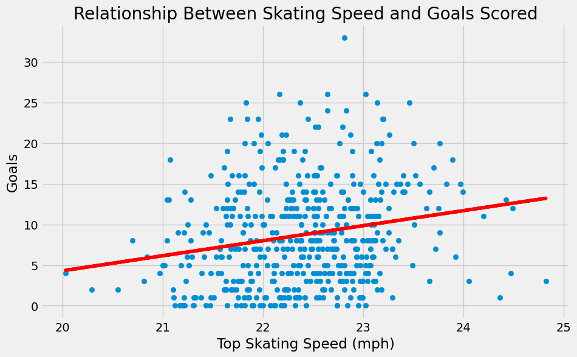

```python
import matplotlib.pyplot as plt
import numpy as np

plt.figure(figsize=(10,6))
#assining values to each axis.
x = full_forward_stats['Top Speed']
y = full_forward_stats['G']
#creat a line of best fit
m, b = np.polyfit(x, y, 1)

plt.plot(x, m*x + b, color='red')

plt.scatter(x, y)

plt.xlabel("Top Skating Speed (mph)")
plt.ylabel("Goals")
plt.title("Relationship Between Skating Speed and Goals Scored")

plt.grid(True)
plt.show()
```

Now, doing the same thing to investigate how a players make shot speed affects their goal scoring. As shown, top shot speed seems to affect the amount of goals scored more than top skating speed.

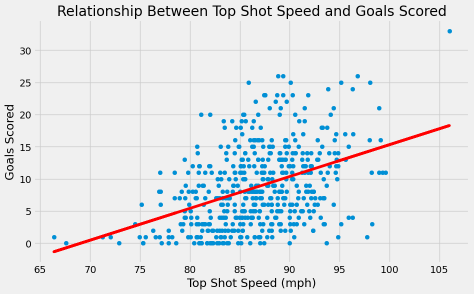

```python
plt.figure(figsize=(10,6))

x = full_forward_stats['Top Shot Speed']
y = full_forward_stats['G']

m, b = np.polyfit(x, y, 1)

plt.plot(x, m*x + b, color='red')

plt.scatter(x, y)

plt.xlabel("Top Shot Speed (mph)")
plt.ylabel("Goals Scored")
plt.title("Relationship Between Top Shot Speed and Goals Scored")

plt.grid(True)
plt.show()
```

Lastly, before moving into machine learning analysis, I want to view how each variable effects the other to see if something stands out. A correlation plot shows the relationships between the each different variable in the called dataframe.

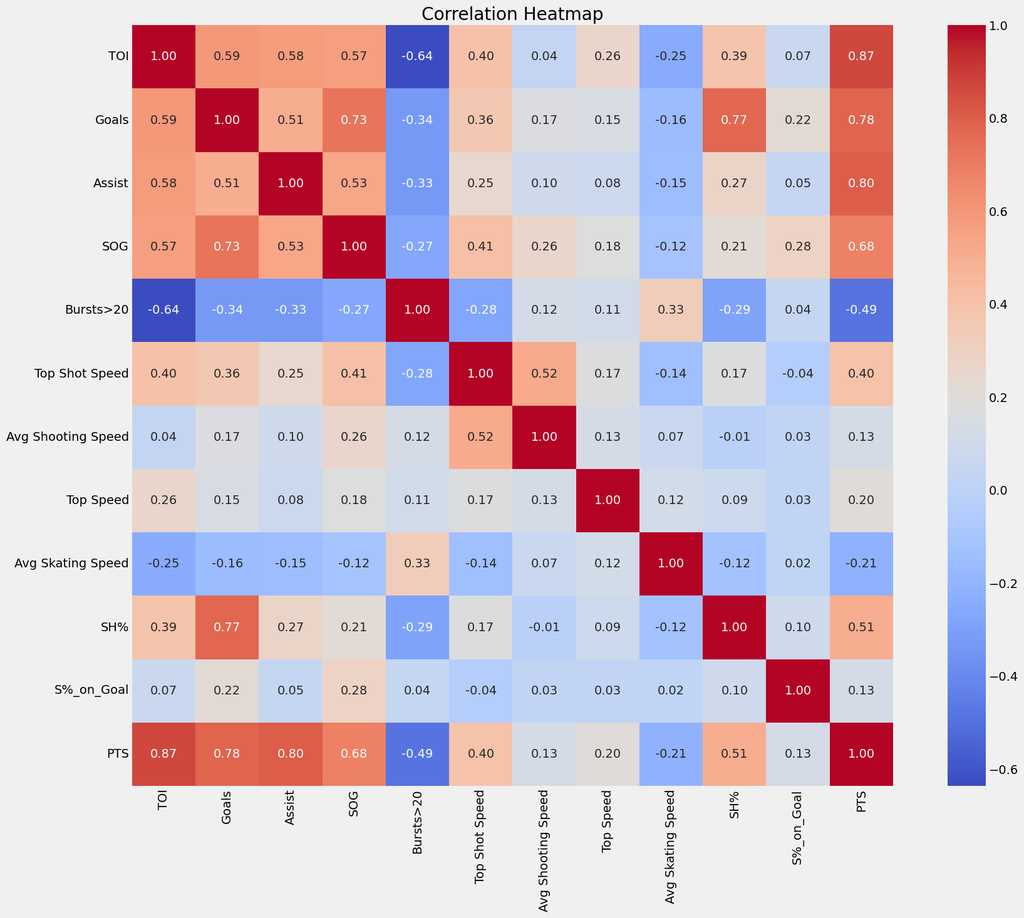

```python
import seaborn as sns
import matplotlib.pyplot as plt

corr_df = stats_per_game.drop(columns=['Player'])

plt.figure(figsize=(20, 15))
sns.heatmap(corr_df.corr(), annot=True, cmap='coolwarm', fmt=".2f", square=True)

plt.title("Correlation Heatmap")
plt.show()
```

Now, to test is the trends are reliable, test the data with a Pearson correlation test. p-values under 0.05 mean the data is very unlikely if there is zero correlation between the two variables.

```python
from scipy.stats import pearsonr

r, p = pearsonr(full_forward_stats['Top Shot Speed'], full_forward_stats['G'])

print("Correlation:", r)
print("p-value:", p)

r, p = pearsonr(full_forward_stats['Top Speed'], full_forward_stats['G'])

print("Correlation:", r)
print("p-value:", p)

r, p = pearsonr(full_forward_stats['SOG'], full_forward_stats['G'])

print("Correlation:", r)
print("p-value:", p)
```

```
Correlation: 0.40824139411285487
p-value: 2.9017825196031444e-21
Correlation: 0.2062109564917435
p-value: 3.8112632245169017e-06
Correlation: 0.8517726674243922
p-value: 3.1623360903803494e-140
```

The p values are low for all three, indicating that Top Shot Speed, Top Speed, and SOG are all related to scoring goals. To further explore any trends, I will use Multivariable Linear Regression. The linear regression model will create a line of best fit from all the given variables and determine the magnitude of effect each given variable has on the variation of y, which in this case is goals. The variables tested are listed in features_to_test.

```
              Feature  Coefficient
0      Top Shot Speed     0.000022
1           Top Speed    -0.002704
2   Avg Skating Speed    -0.007160
3  Avg Shooting Speed     0.000305
4           Bursts>20    -0.086257
5                 TOI     0.000072
6                 SOG     0.087423
Variance score: 0.5290403102471416
```

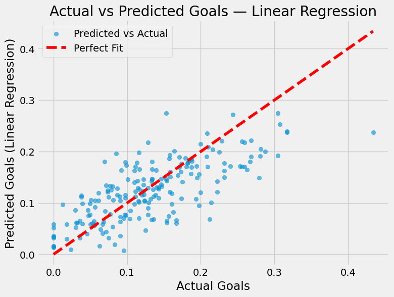

```python
from sklearn.model_selection import train_test_split
import matplotlib.pyplot as plt
import numpy as np
from sklearn import datasets, linear_model, metrics
import pandas as pd
features_to_test = [
    'Top Shot Speed',
    'Top Speed',
    'Avg Skating Speed',
    'Avg Shooting Speed',
    'Bursts>20',
    'TOI',
    'SOG',
]
X = stats_per_game[features_to_test]
y = stats_per_game['Goals']
X_train, X_test, y_train, y_test = train_test_split(X, y, test_size=0.4, random_state=42)
reg = linear_model.LinearRegression()
reg.fit(X_train, y_train)
#Dataframe to cleanly print out the features and their coefficients.
coef_df = pd.DataFrame({'Feature': features,'Coefficient': reg.coef_})

print(coef_df)

# variance score: 1 means perfect prediction. meausure of how much the linear regression line covers variance.
print('Variance score: {}'.format(reg.score(X_test, y_test)))
y_pred = reg.predict(X_test)

plt.figure(figsize=(8, 6))
plt.scatter(y_test, y_pred, alpha=0.6, label="Predicted vs Actual")

# creating prediction reference line
min_val = min(y_test.min(), y_pred.min())
max_val = max(y_test.max(), y_pred.max())
plt.plot([min_val, max_val], [min_val, max_val], 'r--', label="Perfect Fit")
#make the plot of actual vs predictged goals
plt.xlabel("Actual Goals")
plt.ylabel("Predicted Goals (Linear Regression)")
plt.title("Actual vs Predicted Goals — Linear Regression")
plt.legend()
plt.show()
```

Based on the feature coefficients, Shots on Goal has the largest influence on scoring goals. This makes sense; you can't score if you do not shoot the puck. Below is a graph of the residuals from the Linear Regression. This plot shows where the values differ from the line of best fit and if they are part of the training vs test data

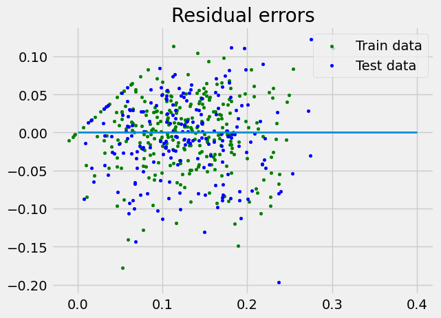

```python
plt.style.use('fivethirtyeight')

# plotting residual errors in training data
plt.scatter(reg.predict(X_train),
            reg.predict(X_train) - y_train,
            color="green", s=10,
            label='Train data')

# plotting residual errors in test data
plt.scatter(reg.predict(X_test),
            reg.predict(X_test) - y_test,
            color="blue", s=10,
            label='Test data')

# plotting line for zero residual error
plt.hlines(y=0, xmin=0, xmax=0.4, linewidth=2)

# plotting legend
plt.legend(loc='upper right')

# plot title
plt.title("Residual errors")

# method call for showing the plot
plt.show()
```

Alternativly to the linear regression model, a decision tree model can be used. The decision tree differs from the linear regression model.

```
R² score: 0.5196406790826562
RMSE: 0.05365396991056511
```

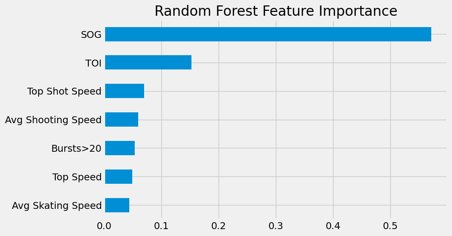

```
RandomForestRegressor(n_estimators=300, random_state=42)
```

```python
from sklearn.ensemble import RandomForestRegressor
from sklearn.model_selection import train_test_split
from sklearn.ensemble import RandomForestRegressor
from sklearn.metrics import r2_score, mean_squared_error


#training data split
X_train, X_test, y_train, y_test = train_test_split(
    X, y, test_size=0.2, random_state=42
)

rf = RandomForestRegressor(
    n_estimators=300,
    max_depth=None,
    min_samples_split=2,
    min_samples_leaf=1,
    random_state=42
)

rf.fit(X_train, y_train)

y_pred = rf.predict(X_test)
#print r^2 score and rmse to see the accuracy of the decision tree.
print("R² score:", r2_score(y_test, y_pred))
rmse = mean_squared_error(y_test, y_pred) ** 0.5
print("RMSE:", rmse)

# Fix: 'features' variable was undefined. Use X.columns for feature names.
importance = pd.Series(rf.feature_importances_, index=X.columns)
importance.sort_values().plot(kind='barh', figsize=(8,5))
plt.title("Random Forest Feature Importance")
plt.show()

model = RandomForestRegressor(n_estimators=300, random_state=42)
model.fit(X, y)
```

Both the Linear Regression and Decision Tree models have very similar R^2 scores. Neither of the scores are very high so the results can only trusted so much. More data could be used to increase the scores. Both models found that shots on goal is the most important variable for scoring goals. While other factors, like top skating speed can play a minor role. It can be concluded that if you want to score goals, shoot the puck.